# Reproducible Research: Peer Assessment 1

## Loading necessary libraries

```r
library(ggplot2)
```

## Loading and preprocessing the data

```r
dataset = read.csv("activity.csv")
summary(dataset)
```

```
##      steps                date          interval
##  Min.   :  0.00   2012-10-01:  288   Min.   :   0.0
##  1st Qu.:  0.00   2012-10-02:  288   1st Qu.: 588.8
##  Median :  0.00   2012-10-03:  288   Median :1177.5
##  Mean   : 37.38   2012-10-04:  288   Mean   :1177.5
##  3rd Qu.: 12.00   2012-10-05:  288   3rd Qu.:1766.2
##  Max.   :806.00   2012-10-06:  288   Max.   :2355.0
##  NA's   :2304     (Other)   :15840
```

There are 2304 entries with NA values. I will omit these entries.

```r
dataset = na.omit(dataset)
```

## What is the mean total number of steps taken per day?

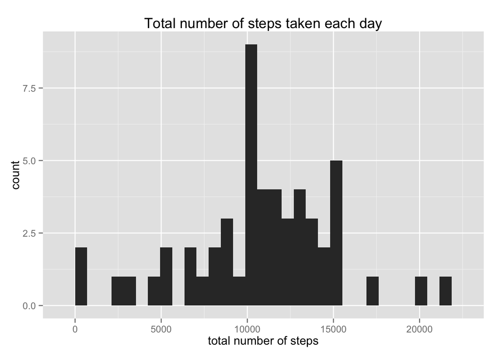

```r
#Compute the total number of steps per day
total_nr_steps = sapply(unique(dataset$date), function(x){sum(dataset[dataset$date == x,'steps'])})

#plotting
ggplot(data.frame(total_nr_steps)) +
    geom_histogram(aes(x=total_nr_steps)) +
    ggtitle("Total number of steps taken each day") +
    labs(x="total number of steps")
```

The mean number of total steps per day is **10766.19** and the median is **10765**.

## What is the average daily activity pattern?

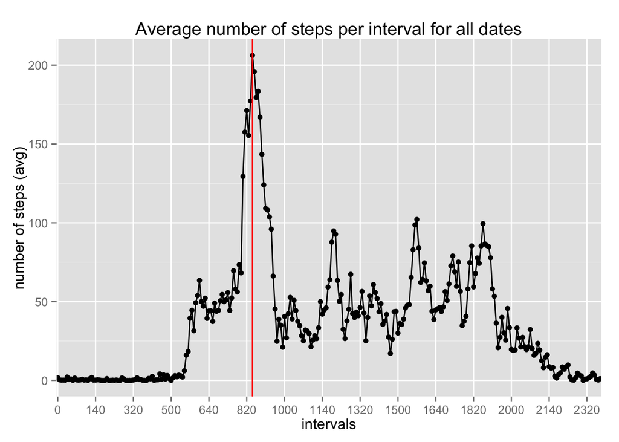

```r
nr_intervals                         = length(unique(dataset$interval))
average_nr_steps_per_interval        = rep(0,nr_intervals)
names(average_nr_steps_per_interval) = unique(dataset$interval)

#Compute the average number of steps per interval over all dates
average_nr_steps_per_interval        = sapply(
    names(average_nr_steps_per_interval),
    function(x){mean(dataset[dataset$interval==x,'steps'])})


#plotting
plot_df = data.frame(
    intervals     = factor(names(average_nr_steps_per_interval), as.character(names(average_nr_steps_per_interval))),
    average_steps = average_nr_steps_per_interval)
ggplot(plot_df, aes(x=intervals, y=average_steps, group=1)) +
    geom_point() +
   geom_line() +
    ggtitle("Average number of steps per interval for all dates") +
    labs(y="number of steps (avg)") +
    geom_vline(xintercept=which.max(average_nr_steps_per_interval), color="red") +
    scale_x_discrete(breaks=names(average_nr_steps_per_interval)[seq(1,nr_intervals,20)])
```

The interval containing on average the maximum number of steps is interval **835** (that is 8.35am to 8.40am).

## Imputing missing values

```r
dataset = read.csv("activity.csv")
```

There are 2304 entries with NA values.

I will impute missing values by setting them to the interval mean of the dataset.

```r
dataset[which(is.na(dataset)),'steps'] = average_nr_steps_per_interval[as.character(dataset[which(is.na(dataset)),'interval']) ]
summary(dataset)
```

```
##      steps                date          interval
##  Min.   :  0.00   2012-10-01:  288   Min.   :   0.0
##  1st Qu.:  0.00   2012-10-02:  288   1st Qu.: 588.8
##  Median :  0.00   2012-10-03:  288   Median :1177.5
##  Mean   : 37.38   2012-10-04:  288   Mean   :1177.5
##  3rd Qu.: 27.00   2012-10-05:  288   3rd Qu.:1766.2
##  Max.   :806.00   2012-10-06:  288   Max.   :2355.0
##                   (Other)   :15840
```

Now we are repeating the analysis from before with the dataset containing the imputed values and check for differences in the mean and median for the total number of steps per day.

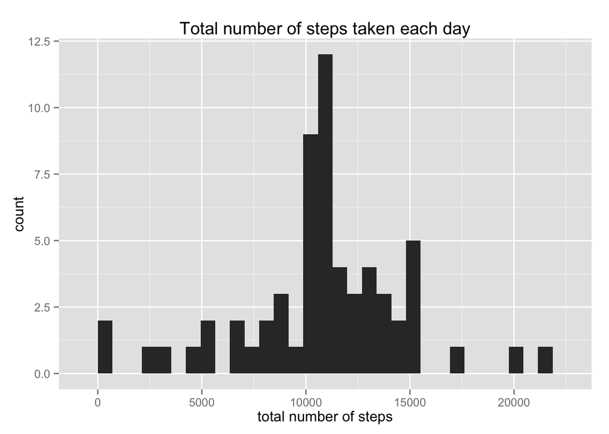

```r
#Compute the total number of steps per day
total_nr_steps = sapply(unique(dataset$date),
                        function(x){ sum(dataset[dataset$date == x,'steps']) })

#plotting
ggplot(data.frame(total_nr_steps)) +
    geom_histogram(aes(x=total_nr_steps)) +
    ggtitle("Total number of steps taken each day") +
    labs(x="total number of steps")
```

The mean number of total steps per day is **10766.19** and the median is **10766.19**.

The mean number of total steps per day for the imputed dataset is the same as for the datset for which I removed the missing values. This makes sense, as I imputed missing values as the mean of the intervals. The median changed only slightly. Therefore we can conclude that imputing values in this dataset has no tremendous impact on the analysis.

## Are there differences in activity patterns between weekdays and weekends?

We now repeat the analysis on daily activity patterns with respect to weekday/weekend.

```r
#Compute weekday/weekend for all dates in dataset
dataset$weekday = ifelse(weekdays(as.Date(dataset$date)) == "Sonntag" | weekdays(as.Date(dataset$date)) == "Samstag", "weekend", "weekday")
table(dataset$weekday)
```

```
##
## weekday weekend
##   12960    4608
```

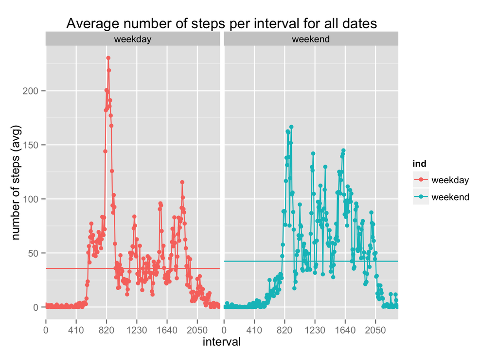

```r
nr_intervals                  = length(unique(dataset$interval))
average_nr_steps_per_interval = data.frame(
    interval = factor(unique(dataset$interval)),
    weekend  = rep(0,nr_intervals), weekday=rep(0,nr_intervals))

#Calculate the average number of steps per interval per weekend/weekday
average_nr_steps_per_interval$weekend = as.numeric(sapply(
    average_nr_steps_per_interval$interval,
    function(x){mean(dataset[dataset$interval==x & dataset$weekday == "weekend",'steps'])}))
average_nr_steps_per_interval$weekday = as.numeric(sapply(
    average_nr_steps_per_interval$interval,
    function(x){mean(dataset[dataset$interval==x & dataset$weekday == "weekday",'steps'])}))

#plotting
plot_df          = stack(average_nr_steps_per_interval, select=c(weekend, weekday))
plot_df$interval = average_nr_steps_per_interval$interval
ggplot(plot_df, aes(x=interval, y=values, group=ind, colour=ind)) +
    geom_point() +
    geom_line() +
    geom_line(stat = "hline", yintercept = "mean")+
    facet_wrap(~ ind) +
    ggtitle("Average number of steps per interval for all dates") +
    labs(y="number of steps (avg)") +
    scale_x_discrete(breaks=plot_df$interval[seq(1,nr_intervals,50)])
```

We can see that the maximum number of steps is higher on weekdays than on weekends. However, on weekends the amount of intervals with intermediate step numbers (say, 100-200) is higher compared to weekdays. This fact is also visible when comparing the mean number of steps on weekends and weekdays (horizontal lines in plot): it is higher on weekends(42.37) than on weekdays(35.61).